# Summary

To investigate if the technique of `machine learning` can be used to optimise the mangement of natural areas, data is used of the pastures in ‘Rome’, situated near Drachten (the Netherlands). A model is constructed using local abiotic data that is possibly relevant to the occurence of ‘blue grassland’ (Cirsio dissecti-Molinietum).

It turned out that the constructed model is well capable of predicting the present occurance of ‘blue grassland’. The model shows that, in a selected plot, a rising of the groundwater table can contribute significantly to the development of ‘blue grassland’.

The technique being used may help to find optimal growing conditions for natural vegetations in other natural areas.

The results of this research is published in a professional journal ([H2O](https://www.h2owaternetwerk.nl/vakartikelen/optimalisatie-van-natuurbeheer)).

Research should be reproducable. Therefore the data and scripts used for this research are made available:

- Data: [R-package](https://github.com/KVIsweco/DataBlauwgraslandRome).
- Scripts are included in the file `AnalyseBlauwgraslandRome.Rmd`.

# Samenvatting

Om te onderzoeken of de techniek van `machine learning` bruikbaar is om het beheer in een natuurgebied te optimaliseren zijn de gegevens gebruikt van het schraallandgebied Rome, gelegen nabij Drachten (FR). Er is een model geconstrueerd dat gevoed is met abiotische gegevens die mogelijk samenhangen met het voorkomen van blauwgrasland.

Het geconstrueerde model blijkt goed in staat te zijn het huidige voorkomen van blauwgrasland te verklaren. Het model laat zien dat in een geselecteerd perceel een verhoging van de grondwaterstand wezenlijk kan bijdragen aan de ontwikkeling van blauwgrasland.

De techniek kan helpen om ook in andere natuurgebieden de locatie specifieke optimale groeiomstandigheden te vinden voor natuurlijke vegetaties.

Onderzoek moet reproduceerbaar zijn. Daarom zijn de voor dit onderzoek gebruikte gegevens en scripts beschikbaar gesteld:

- Data: [R-package](https://github.com/KVIsweco/DataBlauwgraslandRome).
- Scripts are included in the file `AnalyseBlauwgraslandRome.Rmd`.

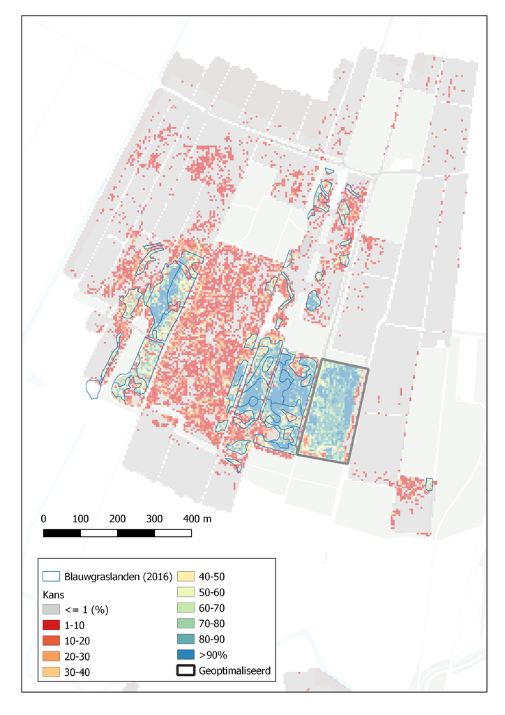

Figuur 5 Berekende kans op blauwgrasland